# The Importance of Data Evaluation in Neurophysiologic Analysis

## Executive Summary

Sleep studies have shown that poor sleeping patterns correlate to poorer future mental health in individuals. Therefore today, it's more relevant than ever to study changing sleep stages which constitute these sleep patterns as well as methods used to detect these sleep stages, including the electrooculogram (EOG) often used to detect REM sleep. However, although such techniques conducted in controlled scientific environments can accurately track a subject through the stages of sleep, in uncontrolled environments it's often difficult to attain the same level of preciseness, mostly due to variation in calibration and environmental noise. This limits the people who can study these phenomena, thus limiting scientific development.

Therefore, through software that can visualise varying input parameters on output metrics, thereby testing the model's robustness to noise, users are provided with an invaluable tool to attain near optimal parameters given some signal with its implied range of environmental variation. To obtain the near optimal parameters, a configuration region of interest should be specified by the user to then randomly iterate within this space, yielding performance of the configurated model at each step.

The software was implemented towards signal isolation of eye movement events from an EOG. However, the concept may be generalised to include any time sequential event isolation problems, albeit requiring it's own ground truth generation algorithm. In this case, due to resource constraints, the concept was demonstrated using an SVM classifier alongside four input hyperparameters: classification window, sample proportion, cleaner window and cleaner threshold.

## Introduction

Polysomnography (PSG) is a form of sleep study that categorises sleeping patterns in two stages, Rapid Eye Movement (REM) sleep or Non-Rapid Eye Movement (NREM) sleep. With a recent study showing 60% of Australians reporting at least one sleep symptom occurring three or more times per week, neupherological techniques such as polysomnography can be used in identifying and diagnosing such disorders. In aiming to identify and diagnose sleep disorders such as sleep apnea, narcolepsy and periodic limb movements, different physiologic signals can be recorded such as eye movements using an electrooculogram (EOG) (Mayo Clinic, 2018). In EOG, two electrodes are placed on the right and left outer canthus to record horizontal eye movements that are picked up as inherent voltage, as the cornea has a positive charge and retina has a negative charge (Armon, C., 2020). By documenting these eye movements, REM sleep can be monitored in evaluating such sleeping disorders. A clinical study conducted in 2014 aimed to evaluate the importance of neurophysiologic techniques i.e. sleep recordings in patients with prolonged disorders of consciousness (De Biase, S., et al. 2014). Results showed that patients with sleep recordings displayed better clinical scores than those who didn't, with REM sleep being the only sleep element achieving statistical significance. Using multivariate analysis, REM sleep was associated with higher Coma Recovery Scale-Revised (CRS-R) scores, proving PSG records to be a reliable tool in conducting a neurophysiological assessment in patients with such sleeping disorders.

The key problems in polysomnography data analysis include poor, noisy data quality, the selection of relevant information and the classification process itself. These three problems are explored using REM data in focusing mainly on the significant features extracted. Also known as the dreaming state, REM occurs when brain waves are most active during sleep and can be quantitatively classified as between 7 to 23 eye movements per minute in which anything above and below this range is considered wakefulness or other NREM stages respectively. Using a spikerbox from Backyard Brains, these stages of wakefulness, REM and NREM can be recorded using the same proven parameters. By replicating a PSG tool using a spikerbox, data analytics can be explored in understanding how various parameters contribute to neurophysiological conclusions such as predicting REM and NREM sleep. The emphasis on the interdisciplinary approach ensures that the main issues in current neurophysiological tools being biased to different sleep stages is monitored, dedicating the central focus of this project on extracting descriptive features from a collection of PSG data (Chaberova, J., 2017).

## Analysis

This report consists of 3 sections. The first section consists of collecting, cleaning and extracting features of the .wav data to predict eye movements based on the SVM classifier and the default parameters using matplotlib. In the second section, the method of deployment is illustrated and randomisation of results is obtained and analysed in deducing the optimal values for both the 3 eye movements (short) and 8 eye movements (long). Finally, the third section adapts results from section 1 using these optimal values in order to demonstrate improved results.

```python
from IPython.display import display
from IPython.display import HTML
import IPython.core.display as di

di.display_html('<script>jQuery(function() {if (jQuery("body.notebook_app").length == 0) { jQuery(".input_area").toggle(); jQuery(".prompt").toggle();}});</script>', raw=True)

di.display_html('''<button onclick="jQuery('.input_area').toggle(); jQuery('.prompt').toggle();">Toggle code</button>''', raw=True)
```

### Section 1: Data Collection and Classifcation Process

REM sleep data is filtered and saved as a waveform data. This data is filtered using a Gaussian Filter, a specific Fast Fourier transform filter method. “Fast Fourier transform plays a key role in physics because it can be used as a mathematical tool to describe the relationship between the time domain and frequency domain representation of discrete signals” (Nussbaumer 1981). This way, waveform data is converted from time domain into frequency domain where appropriate analysis can be performed. Gaussian filter is applied for noise suppression where the noise is smoothed out, at the same time the signal is distorted (Cahiill, Deng 1993). Through these two filtrations, waveform features can be extracted.

“Measures of central tendency tells researchers where the center value lies in the distribution of data” (Allen 2017). Central tendencies collect features in waveform data to find the presence of eye movements after noise suppression in the frequency domain. These are further equipped with the presence of supervised machine learning and continuous eye movements. Supervised machine learning classifiers are used in REM sleep analysis as instances in waveform data can be labelled as eye movement or not. Waveform data are trained and tested after the measure of central tendency to make reliable future predictions. Continuous eye movements remove anomalous predictions and count contiguous predictions from these classifiers to count the number of eye movements present.

Evaluations of classifiers are measured with F1 score. This is because “harmonic mean of precision and recall makes F1 score to be widely used as a measure of success of a binary classifier” (Zachary 2014).Classifiers and F1 scores are computed through Python Scikit-learn library. This library is well suited for statistical data analysis by non-specialists in the software and web industries, as well in the fields outside computer science, such as biology or physics. In particular, the accuracy yielded by F1 score that calculates number of eye movements will be used as an intermediate that measures different parameters interactions upon analysing the waveform data.

In maintaining reproducibility, the classifier of interest is Support Vector Machine (SVM) based on the data type and the preprocessing methods. SVM is a supervised machine learning algorithm that finds the optimal hyperplane of the variable margin size to separate and classify classes of data points in feature space. The standard four parameters of Classification Window Size, Sample Proportion, Cleaner Window, Cleaner Threshold and the extra parameter, SVM cost can be explained in terms of their usage within the SVM classifier. Classification window size sets the size of the window which scans through the data and in which classifications are performed. Sample proportion can speed up the classification latency for large sets of data by only running through a chosen proportion of the entire data. Cleaner Window takes a chosen number of consecutive classification windows and identifies an eye movement if the ratio of positive events to the number of chosen windows is greater than the Cleaner Threshold, which is a number between 0 and 1. Finally, SVM cost is the extra classifier parameter that allows you to adjust how large (soft) or narrow (hard) your margin classification should be. For example, decreasing cost will correspond to increasing margin and will be more flexible with misclassifications.

Pre-recorded datas is collected by Arduino and saved as a wav file. These datas are filtered using Fast Fourier Transform. FFT filter is used to make the data into a function of frequency. Once datas is filtered, central tendencies features are collected through the wav files to get any movements in the data. Presence of continuous eye movements can be encountered through the use of window sequence cleaner. This cleaner removes anomalous predictions and counts contiguous predictions in the extracted data to find the number of eye movements present.

```python
import warnings
def warn(*args, **kwargs):
    pass
warnings.warn = warn

import pickle
from models.Data import Data
%matplotlib inline

user_input_short = "assets/AAA.wav"
user_input_long = "assets/AAAAAAAA.wav"
```

[output not shown]

The .wav files for short and long files are explored in the analysis to determine interaction between the length of the file, input hyperparameters and output metrics. Results of both .wav files can be seen below:

```
Data => analyseData()
FeatureSelector => findKPeaks()
FeatureSelector => getFeatures()
WindowClassifier => handlePredict()
WindowClassifier => predictSVM()
Data => cleanPrediction()

Figure 1. event predictions (dark green) of a 3 movement signal sample generated through EOG.
```

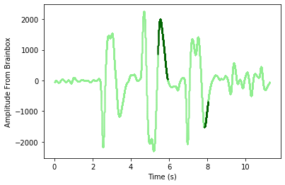

```python
user_analysis = {
    "classifierType": "svm",
    "classifierStep": 100,
    "classifierWindow": 1000,
    "classifierProportion": 0.001,
    "cleanerWindow": 100,
    "cleanerProportion": 0.8,
    "extraParameter": 1
}
user = Data(user_analysis, user_input_short)
user.analyseData()
user.cleanPrediction()

print()
print("Figure 1. event predictions (dark green) of a 3 movement signal sample generated through EOG.")

user.createFigure()
```

```python
# Number of eye mveoemnts
print("Count: {}".format(user.get_count()))
```

```
Count: 2
```

```
Data => analyseData()
FeatureSelector => findKPeaks()
FeatureSelector => getFeatures()
WindowClassifier => handlePredict()
WindowClassifier => predictSVM()
Data => cleanPrediction()

Figure 2. event predictions (dark green) of a 8 movement signal sample generated through EOG.
```

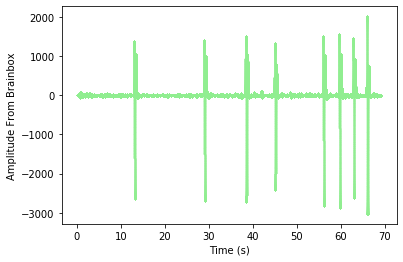

```python
user = Data(user_analysis, user_input_long)
user.analyseData()
user.cleanPrediction()

print()
print("Figure 2. event predictions (dark green) of a 8 movement signal sample generated through EOG.")

user.createFigure()
```

```python
print("Count: {}".format(user.get_count()))
```

```
Count: 0
```

No movement is detected in the long wav. This result is expected as different wav file has different calibration which. During the experiment setup, long wav file is not sufficient spaced and more erratic in its spacing. To find parameters optimization, a randomization is required.